# Tutorial for computing polygenic risk score using GXwasR R package.

By Banabithi Bose

2024-01-16

**This document provides a tutorial for computing state-of-the-art polygenic risk score and sex-aware ploygenic risk score utilizing GXwasR R package.**

```r
## Call some libraries (Users can ignore this.)
library(printr)
library(rmarkdown)
```

## Call GXwasR library and load example datasets:

```r
## Call GXwasR library
library(GXwasR)
## Load the example .Rda files
data("GXwasRData")
```

## Computing standard PRS using ComputePRS():

### About ComputePRS()

```r
help(ComputePRS, package = GXwasR)
```

| ComputePRS | R Documentation |
| --- | --- |

## ComputePRS: Computing polygenic risk score (PRS)

### Description

This function calculates the polygenic risk score, which is the total of allele counts (genotypes) weighted by estimated effect sizes from genome-wide association studies. It uses C+T filtering techniques. The users could perform clumping procedure choromosome-wise and genome-wide. Also, the function offers the choice of including several genetic principal components along with other covariates. Using this function, users have the freedom to experiment with various clumping and thresholding arrangements to test a wide range of various parameter values.

### Usage

```r
ComputePRS(
  DataDir,
  ResultDir = tempdir(),
  finput,
  summarystat,
  phenofile,
  covarfile = NULL,
  effectsize = c("BETA", "OR"),
  ldclump = FALSE,
  LDreference,
  clump_p1,
  clump_p2,
  clump_r2,
  clump_kb,
  byCHR = TRUE,
  pthreshold = c(0.001, 0.05, 0.1, 0.2, 0.3, 0.4, 0.5),
  highLD_regions = "high-LD-regions-hg19-GRCh37.txt",
  ld_prunning = FALSE,
  window_size = 50,
  step_size = 5,
  r2_threshold = 0.02,
  nPC = 6,
  pheno_type = "binary"
)
```

### Arguments

| `DataDir` | A character string for the file path of the all the input files. |
| --- | --- |
| `ResultDir` | A character string for the file path where all output files will be stored. The default is tempdir(). |
| `finput` | Character string, specifying the prefix of the input PLINK binary files for the genotype data i.e., the target data based on which clumping procedure will be performed. This file needs to be in DataDi… |
| `summarystat` | A dataframe object with GWAS summary statistics. The mandatory column headers in this dataframe are 'CHR'(Chromosome code), 'BP'(Basepair position), 'A1' (effect allele), ‘SNP’ (i.e., SNP idenitifier)… |
| `phenofile` | A character string, specifying the name of the mandatory phenotype file. This is a plain text file with no header line; columns family ID, individual ID and phenotype columns. For binary trait, the ph… |
| `covarfile` | A character string, specifying the name of the covariate file which is a plain .text file with no header line; columns are family ID, individual ID and the covariates. The default is NULL. This file n… |
| `effectsize` | Boolean value, ‘BETA’ or ‘OR’, specifying the type of the GWAS effectsize. The default is ‘BETA’. |
| `ldclump` | Boolean value, 'TRUE' or 'FALSE', specifying whether to perform clumping or not. |
| `LDreference` | A character string, specifying the prefix of the PLINK files of the population reference panel of the same ancestry, and ideally the one that was used for imputing your target dataset. These files sho… |
| `clump_p1` | Numeric value, specifying the significance threshold for index SNPs if 'ldclump' was set to be TRUE. The default is 0.0001. |
| `clump_p2` | Numeric value, specifying the secondary significance threshold for clumped SNPs if 'ldclump' was set to be TRUE. The default is 0.01 |
| `clump_r2` | Numeric value, specifying the linkage disequilibrium (LD) threshold for clumping if 'ldclump' was set to be TRUE. The default is 0.50. |
| `clump_kb` | Integer value, specifying the physical distance threshold in base-pair for clumping if 'ldclump' was set to be TRUE. The default is 250. |
| `byCHR` | Boolean value, 'TRUE' or 'FALSE', specifying chromosome-wise clumping procedure if 'ldclump' was set to be TRUE. The default is TRUE. |
| `pthreshold` | Numeric vector, containing several p value thresholds to maximize predictive ability of the derived polygenic scores. |
| `highLD_regions` | Character string, specifying the .txt file name with known genomic regions with high LD. The default is NULL. |
| `ld_prunning` | Boolean value, 'TRUE' or 'FALSE' for LD-based filtering for computing genetic PC as covariates. |
| `window_size` | Integer value, specifying a window size in variant count or kilobase for LD-based filtering in computing genetic PC. The default is 50. |
| `step_size` | Integer value, specifying a variant count to shift the window at the end of each step for LD filtering in computing genetic PCs. The default is 5. |
| `r2_threshold` | Numeric value between 0 to 1 of pairwise r^2 threshold for LD-based filtering in computing genetic PCs. The default is 0.02. |
| `nPC` | Positive integer value, specifying the number of genetic PCs to be included as predictor in the PRS model fit. The default is 6. |
| `pheno_type` | Boolean value, ‘binary’ or ‘quantitative’, specifying the type of the trait. The default is ‘binary’. |

### Value

A list object containing a dataframe and a numeric value. The dataframe,PRS, contains four mandatory columns, such as, IID (i.e., Individual ID), FID (i.e., Family ID), Pheno1 (i.e., the trait for PRS) and Score (i.e., the best PRS). Other columns of covariates could be there. The numeric value, BestP contains the threshold of of the best p-value for the best pRS model fit.

Also, the function produces several plots such as p-value thresholds vs PRS model fit and PRS distribution among male and females. For case-control data, it shows PRS distribution among cases and controls and ROC curves as well.

### Examples

```r
DataDir <- system.file("extdata", package = "GXwasR")
ResultDir <- tempdir()
finput <- "GXwasR_example"
data("GXwasRData")
summarystat <- Summary_Stat_Ex1[,c(2,4,7,1,3,12)]
phenofile <- Example_phenofile #Cannot be NULL, the interested phenotype column should be labeled as "Pheno1".
covarfile <- Example_covarfile
clump_p1 = 0.0001
clump_p2 = 0.0001
clump_kb = 500
clump_r2 = 0.5
byCHR = TRUE
pthreshold <- Example_pthresoldfile$Threshold
ld_prunning <- TRUE
highLD_regions <- highLD_hg19
window_size <- 50
step_size <- 5
r2_threshold <- 0.02
nPC = 6 #We can incorporate PCs into our PRS analysis to account for population stratification.
pheno_type = "binary"

PRSresult <- ComputePRS(DataDir,ResultDir,finput,summarystat,phenofile,covarfile,effectsize="BETA",LDreference = "GXwasR_example", ldclump = FALSE,clump_p1,clump_p2,clump_r2,clump_kb, byCHR = TRUE,pthreshold = pthreshold,highLD_regions = highLD_regions, ld_prunning = TRUE,window_size = 50, step_size = 5,r2_threshold = 0.02, nPC = 6,pheno_type = "binary")

## This table shows 10 samples with phenotype, covariates and a PRS column.
PRS <- PRSresult$PRS
PRS[1:10,]
## The best threshold
BestPvalue <- PRSresult$BestP$Threshold
BestPvalue
```

### Running ComputePRS()

```r
# Running
DataDir <- system.file("extdata", package = "GXwasR")
ResultDir <- tempdir()
finput <- "GXwasR_example"
summarystat <- Summary_Stat_Ex1[,c(2,4,7,1,3,12)]
phenofile <- Example_phenofile #Cannot be NULL, the interested phenotype column should be labeled as "Pheno1".
covarfile <- Example_covarfile
clump_p1 = 0.0001
clump_p2 = 0.0001
clump_kb = 500
clump_r2 = 0.5
byCHR = TRUE
pthreshold <- Example_pthresoldfile$Threshold
ld_prunning <- TRUE
highLD_regions <- highLD_hg19
window_size <- 50
step_size <- 5
r2_threshold <- 0.02
nPC = 6 #We can incorporate PCs into our PRS analysis to account for population stratification.
pheno_type = "binary"
ldclump = FALSE
pheno_type = "binary"
PRSresult <- ComputePRS(DataDir,ResultDir,finput,summarystat,phenofile,covarfile,effectsize="BETA",LDreference = "GXwasR_example", ldclump = FALSE,clump_p1,clump_p2,clump_r2,clump_kb, byCHR = TRUE,pthreshold = pthreshold, highLD_regions = highLD_regions, ld_prunning = TRUE,window_size = 50, step_size = 5,r2_threshold = 0.02, nPC = 6,pheno_type = "binary")
```

```
## [1] "Program is set up."
## [1] "Program is set up."
## [1] "plotPC = FALSE was chosen"
## [1] 0.001
## [1] "Computing PRS for threshold 0.001"
## [1] 0.05
## [1] "Computing PRS for threshold 0.05"
## [1] 0.1
## [1] "Computing PRS for threshold 0.1"
## [1] 0.2
## [1] "Computing PRS for threshold 0.2"
## [1] 0.3
## [1] "Computing PRS for threshold 0.3"
## [1] 0.4
## [1] "Computing PRS for threshold 0.4"
## [1] 0.5
## [1] "Computing PRS for threshold 0.5"
## [1] "Plots are initiated."
```

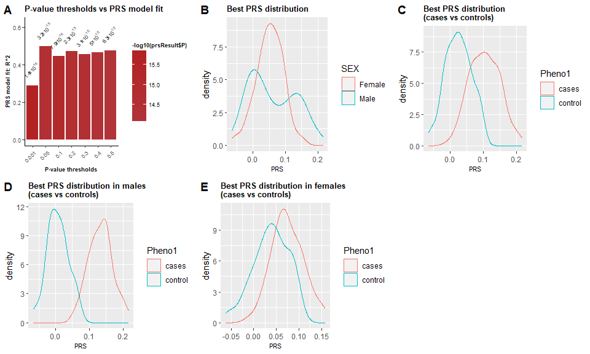

```
## [1] "Plots are printed."
```

```r
## This table shows 10 samples with phenotype, covariates and a PRS column.
PRS <- PRSresult$PRS
PRS[1:10,]
```

| FID | IID | Pheno1 | AGE | testcovar | PC1 | PC2 | PC3 | PC4 | PC5 | PC6 | SCORE |
| --- | --- | --- | --- | --- | --- | --- | --- | --- | --- | --- | --- |
| EUR_FIN | HG00171 | 1 | 36 | 1 | 0.0984270 | 0.0545964 | -0.0128387 | -0.0295421 | 0.0381968 | -0.0338884 | 0.0484212 |
| EUR_FIN | HG00173 | 1 | 81 | 1 | 0.0814620 | 0.0427825 | -0.0353089 | -0.0046323 | -0.0547033 | 0.0234367 | 0.0293742 |
| EUR_FIN | HG00174 | 1 | 83 | 1 | 0.0574856 | 0.0231881 | 0.0074347 | 0.0018039 | -0.0072442 | 0.0242692 | 0.0099674 |
| EUR_FIN | HG00176 | 2 | 75 | 0 | 0.0846743 | 0.0531902 | -0.0239229 | -0.0125275 | 0.0185402 | -0.0232204 | 0.1042060 |
| EUR_FIN | HG00177 | 1 | 88 | 1 | 0.0844408 | 0.0447869 | -0.0623942 | -0.0351411 | -0.0208355 | 0.0764725 | 0.0314303 |
| EUR_FIN | HG00178 | 1 | 24 | 1 | 0.0590789 | 0.0356180 | 0.0225026 | 0.0310004 | 0.0463228 | 0.0212882 | 0.0722689 |
| EUR_FIN | HG00179 | 2 | 78 | 1 | 0.0858355 | 0.0325418 | -0.0140910 | 0.0264206 | -0.0449786 | 0.0054808 | 0.1165240 |
| EUR_FIN | HG00180 | 1 | 39 | 1 | 0.0926786 | 0.0389852 | 0.0080128 | 0.0158442 | 0.0253621 | -0.0609059 | 0.0617159 |
| EUR_FIN | HG00182 | 1 | 50 | 1 | 0.0884415 | 0.0535143 | -0.0150184 | 0.0237222 | -0.0630822 | -0.0074837 | 0.0283703 |
| EUR_FIN | HG00183 | 1 | 58 | 0 | 0.0841885 | 0.0497837 | -0.0166280 | -0.0271598 | -0.0113098 | -0.0216147 | 0.0386297 |

```r
## The best threshold
BestPvalue <- PRSresult$BestP$Threshold
BestPvalue
```

```
## [1] 0.05
```

## Computing sex-aware PRS

### Datasets for computing PRS

**Discovery Data** i.e., GWAS summary statistics with mandatory columns such as “SNP”(SNP names), “A1”(effect allele), “BETA”(effect size in beta value) and “P”(p-value).

```r
#Example discovery data is included in GXwasR
library(GXwasR)
data("GXwasRData")
summarystat <- Summary_Stat_Ex1[,c(2,4,7,1,3,12)]
```

**Target Data** i.e., genotype dataset in plink .bed, .bim and .fam format.

```r
# Example target data is included in GXwasR
DataDir <- system.file("extdata", package = "GXwasR")
finput <- "GXwasR_example"
```

### Quality control of the datasets before computing sex-aware PRS.

Users must ensure that both datasets are having the **same genome built**. Here’s the quality control procedure:

**(A) Discovery Data: Remove multi-allelic, indels and ambiguous (A/T or C/G) SNPs. Then remove SNPs with minor allele frequency (MAF) < 0.05 and quality info score < 0.1. For this filtering, R packages like data.table, dplyr, tidyverse can be used.**

**(B) Target Data: Remove multi-allelic, indels and ambiguous (A/T or C/G) SNPs. Then remove SNPs with MAF < 0.05 and Hardy Weinberg Equlibrium (hwe) > e-10. For this filtering steps, users should use FilterAllele() and QCsnp() functions in R.**

We will use FilterAllele() on target data to filter out the multi-allelic SNPs. Also, note that GXwasR doesn’t work with multi-allelic variants. So this filtering step is important.

```r
#Target data
DataDir <- system.file("extdata", package = "GXwasR")
ResultDir <- tempdir()
finput <- "GXwasR_example"
foutput <- "filtered_multiallelic"
x <- FilterAllele(DataDir, ResultDir, finput, foutput)
```

```
## [1] "Program is set up."
## [1] "There is no multi-allelic SNP present in the input dataset."
```

Now, we will use QCsnp() to remove ambiguous (A/T or C/G) SNPs and SNPs with MAF < 0.05 and Hardy Weinberg Equlibrium (hwe) > e-10.

```r
##Since there was no multiallelic SNPs, we will continue with original input data.
finput <- "GXwasR_example"
foutput <- "filtered_step1"
geno <- NULL
maf <- 0.05
casecontrol <- FALSE
caldiffmiss <- FALSE
diffmissFilter <- FALSE
dmissX <- FALSE
dmissAutoY <- FALSE
monomorphicSNPs <- TRUE
ld_prunning <- FALSE
casecontrol <- FALSE ## Since the filtering doesn't require us to run on cases and controls separately, we will make this parameter FALSE.
hweCase <- NULL
hweControl <- NULL
hwe <- 1e-10
monomorphicSNPs <- FALSE
ld_prunning <- FALSE

x <- QCsnp(DataDir = DataDir, ResultDir = ResultDir, finput = finput,foutput = foutput, geno = geno, maf = maf,hweCase = hweCase, hweControl = hweControl, hwe = hwe, ld_prunning = ld_prunning, casecontrol = casecontrol, monomorphicSNPs = monomorphicSNPs, caldiffmiss = caldiffmiss, dmissX = dmissX, dmissAutoY = dmissAutoY, diffmissFilter = diffmissFilter)
```

```
## [1] "Program is set up."
## [1] "4214 Ambiguous SNPs (A-T/G-C), indels etc. were removed."
## [1] "Thresholds for maf, geno and hwe worked."
## [1] "--hwe: 3 variants removed due to Hardy-Weinberg exact test."
## [2] "5467 variants removed due to minor allele threshold(s)"
## [1] "No filter based on differential missingness will be applied."
## [1] "Output plink files prefixed as ,filtered_step1, with passed SNPs are saved in ResultDir."
## [1] "Input file has 26527 SNPs."
## [1] "Output file has 16843 SNPs after filtering."
```

**(C) Check whether SNPs present in discovery data are in target data.** Let’s gather the common SNPs between these.

```r
SNP1 <- unique(summarystat$SNP)
targetbim <- read.table(paste0(ResultDir,"/filtered_step1.bim"))
SNP2 <- unique(targetbim$V2)
commonSNP <- intersect(SNP1,SNP2)## 991 SNPs are common between our discovery data and target data
```

### Filtering discovery data and target data with common SNPs

```r
commonSNP <- data.table::as.data.table(commonSNP)
colnames(commonSNP) <- "SNP"
NewDiscoveryData <- merge(commonSNP,summarystat,by = "SNP")
## For making target data with common SNPs, we will use FilterSNP().
SNPvec <-commonSNP
#Need to copy filtered_step1 file from ResultDir to DataDir
ftemp <- list.files(paste0(ResultDir,"/"),pattern = "filtered_step1")
invisible(file.copy(paste0(ResultDir,"/",ftemp),DataDir))
finput <- "filtered_step1"
foutput <- "NewtargetData"
FilterSNP(DataDir, ResultDir, finput, foutput, SNPvec,extract = TRUE)
```

```
## [1] "Program is set up."
## [1] "991 SNPs are extracted"
## [1] "Plink files with extracted SNPs are in C:\\Users\\Sarah\\AppData\\Local\\Temp\\RtmpuuME3B prefixed as NewtargetData"
```

Now, our discovery data and target data are ready. We will proceed towards computing first sex-combined PRS and then sex-stratified PRS.

## Sex-combined PRS computation

**(A) Perform LD clumping for discovery data using target data as reference.**

**(B) Compute PRS at a variety of p-value thresholds.**

**(C) Select best threshold based on R-square (for quantitative trait) or MacFadden R-square (for binary trait) using generalized linear model with covariates, such as genetic PCs.**

We will utilize the ComputePRS() to perform the steps (A), (B) and (C).

```r
# Running
# Filtered target data needs to be copied from ResultDir to DataDir.
ftemp <- list.files(paste0(ResultDir,"/"),pattern = "NewtargetData")
invisible(file.copy(paste0(ResultDir,"/",ftemp),DataDir))
finput <- "NewtargetData"

# Filtered discovery data.
# Need to maintain the first three coulmn of this dataset as SNP ID, Effect Allele and Effect Size
summarystat <- NewDiscoveryData
phenofile <- Example_phenofile #Cannot be NULL, the interested phenotype column should be labeled as "Pheno1".
## Added "AGE" and "testcovar" as covariates.
covarfile <- Example_covarfile
clump_p1 = 0.0001
clump_p2 = 0.0001
clump_kb = 500
clump_r2 = 0.5
byCHR = TRUE
pthreshold <- Example_pthresoldfile$Threshold
ld_prunning <- TRUE
highLD_regions <- highLD_hg19
window_size <- 50
step_size <- 5
r2_threshold <- 0.02
nPC = 6  # We can incorporate PCs into our PRS analysis to account for population stratification.
pheno_type = "binary"
effectsize = "BETA"
ldclump = FALSE
PRSresult <- ComputePRS(DataDir,ResultDir,finput,summarystat,phenofile,covarfile,effectsize="BETA",LDreference = "GXwasR_example", ldclump = FALSE,clump_p1,clump_p2,clump_r2,clump_kb, byCHR = TRUE,pthreshold = pthreshold,highLD_regions = highLD_regions, ld_prunning = TRUE,window_size = 50, step_size = 5,r2_threshold = 0.02, nPC = 6,pheno_type = "binary")
```

```
## [1] "Program is set up."
## [1] "Program is set up."
## [1] "plotPC = FALSE was chosen"
## [1] 0.001
## [1] "Computing PRS for threshold 0.001"
## [1] 0.05
## [1] "Computing PRS for threshold 0.05"
## [1] 0.1
## [1] "Computing PRS for threshold 0.1"
## [1] 0.2
## [1] "Computing PRS for threshold 0.2"
## [1] 0.3
## [1] "Computing PRS for threshold 0.3"
## [1] 0.4
## [1] "Computing PRS for threshold 0.4"
## [1] 0.5
## [1] "Computing PRS for threshold 0.5"
## [1] "Plots are initiated."
```

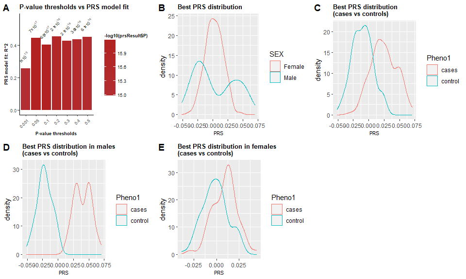

```
## [1] "Plots are printed."
```

```r
## This table shows 10 samples with phenotype, covariates and a PRS column.
PRS <- PRSresult$PRS
PRS[1:10,]
```

| FID | IID | Pheno1 | AGE | testcovar | PC1 | PC2 | PC3 | PC4 | PC5 | PC6 | SCORE |
| --- | --- | --- | --- | --- | --- | --- | --- | --- | --- | --- | --- |
| EUR_FIN | HG00171 | 1 | 36 | 1 | 0.1152000 | 0.0464282 | 0.0189986 | -0.0568381 | 0.0664754 | 0.1181530 | -0.0166680 |
| EUR_FIN | HG00173 | 1 | 81 | 1 | 0.0685788 | 0.0774143 | -0.0441947 | -0.0460358 | 0.0148590 | 0.0180409 | -0.0116780 |
| EUR_FIN | HG00174 | 1 | 83 | 1 | 0.0322192 | 0.0237567 | -0.0208123 | 0.0480590 | 0.0142846 | 0.0012434 | 0.0030211 |
| EUR_FIN | HG00176 | 2 | 75 | 0 | 0.0923099 | 0.0945430 | -0.0258776 | 0.0720050 | -0.0610093 | -0.0227889 | 0.0297140 |
| EUR_FIN | HG00177 | 1 | 88 | 1 | 0.0894694 | 0.0507977 | -0.0201713 | -0.0121658 | 0.0514540 | -0.0094745 | -0.0020329 |
| EUR_FIN | HG00178 | 1 | 24 | 1 | 0.0535609 | -0.0269092 | 0.0531649 | 0.0230253 | 0.0040255 | 0.0438350 | 0.0115410 |
| EUR_FIN | HG00179 | 2 | 78 | 1 | 0.0010501 | 0.0279390 | -0.1512810 | -0.0470689 | -0.0353966 | 0.1357360 | 0.0112993 |
| EUR_FIN | HG00180 | 1 | 39 | 1 | 0.0495020 | -0.1236860 | -0.1585750 | -0.0078017 | -0.1206890 | -0.0168742 | 0.0234045 |
| EUR_FIN | HG00182 | 1 | 50 | 1 | 0.0833507 | 0.0209397 | 0.0113593 | -0.0332595 | -0.0321080 | -0.0223653 | -0.0196350 |
| EUR_FIN | HG00183 | 1 | 58 | 0 | 0.0411108 | -0.0416770 | 0.0282441 | 0.0208968 | -0.0310370 | 0.1355450 | -0.0087472 |

```r
## The best threshold
BestPvalue <- PRSresult$BestP$Threshold
BestPvalue
```

```
## [1] 0.2
```

**(D) Perform regression to test the association of PRS and sex.**

**(E) Perform the regression using different thresholds of PRS to check for consistent evidence of sex difference.**

In this regression, we could include genetic PCs and other covarites as well.

**PRS ~ Sex + PCs + Other Covariates.**

For this test, we will use SexRegress() function.

## About SexRegress()

```r
help(SexRegress, package = GXwasR)
```

| SexRegress | R Documentation |
| --- | --- |

## SexRegress: Performing linear regression analysis with quantitative response variable.

### Description

This function could be used to check association of two variables. For instance, PRS with sex.

### Usage

```r
SexRegress(fdata, regressor_index, response_index)
```

### Arguments

| `fdata` | R dataframe object. The column with header "response" should contain the response variable. All other column are the regressor. |
| --- | --- |
| `regressor_index` | Integer value, specifying the column number of the main regressor variable. |
| `response_index` | Integer value, specifying the column number of the response variable. |

### Value

Numeric value containing the regression estimate ("Estimate"), standard error ("Std. Error"), statistics ("t value") and p-value ("Pr(>|t|)")

### Examples

```r
data("GXwasRData")
fdata = Regression_Ex
fdata$SEX <- as.factor(as.character(fdata$SEX))
response_index <- 1
regressor_index <- 2

x <- SexRegress(fdata, regressor_index, response_index)
```

## Running SexRegress()

```r
# Running
# First, we need to make fdata object.
library(GXwasR)
famfile <- read.table(paste0(ResultDir,"/NewtargetData.fam"))[,c(1,2,5)]
colnames(famfile) <- c("FID","IID","Sex")
prefdata <- merge(famfile, PRS, by = c("IID","FID"))

fdata <- prefdata[,c(13,3:12)]
fdata$Sex <- as.factor(as.character(fdata$Sex))
response_index <- 1
regressor_index <- 2

x <- SexRegress(fdata, regressor_index, response_index)
x
```

```
##      Estimate    Std. Error       t value      Pr(>|t|)
## -0.0001303925  0.0021759687 -0.0599239012  0.9522614090
```

## Sex-stratified PRS

The steps are: **(A) Generate separate male and female discovery data by stratified GWAS.**

**(B) Prepare separate male and female target datasets.**

For this, we will utilize GetMFPlink().

```r
library(GXwasR)
## We will use NewtargetData as input for this function.
finput <- "NewtargetData"
foutput <- "maletarget"
sex <- "males"
x <- GetMFPlink(DataDir = DataDir, ResultDir = ResultDir, finput = finput, foutput = foutput,sex = sex, xplink = FALSE, autoplink = FALSE)
```

```
## [1] "Program is set up."
## [1] "Output plink files, prefixed as maletarget, are in C:\\Users\\Sarah\\AppData\\Local\\Temp\\RtmpuuME3B"
```

```r
foutput <- "femaletarget"
sex <- "females"
x <- GetMFPlink(DataDir = DataDir, ResultDir = ResultDir, finput = finput, foutput = foutput,sex = sex, xplink = FALSE, autoplink = FALSE)
```

```
## [1] "Program is set up."
## [1] "Output plink files, prefixed as femaletarget, are in C:\\Users\\Sarah\\AppData\\Local\\Temp\\RtmpuuME3B"
```

**(C) Perform LD clumping separately in both discovery data.**

**(D) Compute PRS at a variety of p-value thresholds, using male-only discovery data to compute scores for female-only target data and vice versa.**

**(E) Select best threshold based on R-square (for quantitative trait) or MacFadden R-square (for binary trait) using generalized linear model with covariates, such as genetic PCs.**

We will utilize the ComputePRS() to perform the steps (C), (D) and (E).

```r
# Running
# Male and female target datasets need to be copied from ResultDir to DataDir.
ftemp <- list.files(paste0(ResultDir,"/"),pattern = "target")
invisible(file.copy(paste0(ResultDir,"/",ftemp),DataDir))
```

## Computing PRS for female-only target data using male-only dicovery data

```r
DataDir <- system.file("extdata", package = "GXwasR")
ResultDir <- tempdir()
finput <- "femaletarget"
# Filtered discovery data.
# Need to maintain the first three coulmn of this dataset as SNP ID, Effect Allele and Effect Size
summarystat <- Summary_Stat_Ex1[,c(2,4,7,1,3,12)]
## Making phenofile only with females
famfile <- read.table(paste0(ResultDir,"/femaletarget.fam"))[,c(1,2,5)]
colnames(famfile) <- c("FID","IID","Sex")
famfileF <- famfile[famfile$Sex== 2,]
phenofile <- merge(famfileF,Example_phenofile,by = c("FID","IID")) #Cannot be NULL, the interested phenotype column should be labeled as "Pheno1".
## Added "AGE" and "testcovar" as covariates.
## Making cpvarfile with females
covarfile <- merge(famfileF,Example_covarfile,by = c("FID","IID"))
clump_p1 = 0.0001
clump_p2 = 0.0001
clump_kb = 500
clump_r2 = 0.5
byCHR = TRUE
pthreshold <- Example_pthresoldfile$Threshold
ld_prunning <- TRUE
highLD_regions <- highLD_hg19
window_size <- 50
step_size <- 5
r2_threshold <- 0.02
nPC = 6  # We can incorporate PCs into our PRS analysis to account for population stratification.
pheno_type = "binary"
ldclump = FALSE
effectsize="BETA"
PRSresultFemale <- ComputePRS(DataDir,ResultDir,finput,summarystat,phenofile,covarfile,effectsize="BETA",LDreference = "GXwasR_example", ldclump = FALSE,clump_p1,clump_p2,clump_r2,clump_kb, byCHR = TRUE,pthreshold = pthreshold,highLD_regions = highLD_regions, ld_prunning = TRUE,window_size = 50, step_size = 5,r2_threshold = 0.02, nPC = 6,pheno_type = "binary")
```

```
## [1] "Program is set up."
## [1] "Program is set up."
## [1] "plotPC = FALSE was chosen"
## [1] 0.001
## [1] "Computing PRS for threshold 0.001"
## [1] 0.05
## [1] "Computing PRS for threshold 0.05"
## [1] 0.1
## [1] "Computing PRS for threshold 0.1"
## [1] 0.2
## [1] "Computing PRS for threshold 0.2"
## [1] 0.3
## [1] "Computing PRS for threshold 0.3"
## [1] 0.4
## [1] "Computing PRS for threshold 0.4"
## [1] 0.5
## [1] "Computing PRS for threshold 0.5"
## [1] "Plots are initiated."
```

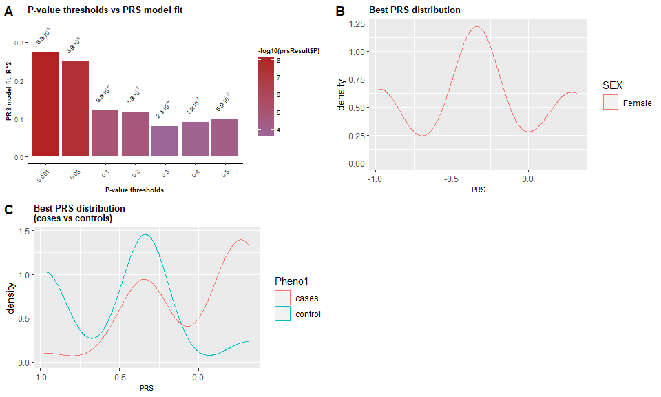

```
## [1] "Plots are printed."
```

```r
## This table shows 10 samples with phenotype, covariates and a PRS column.
PRSfemale <- PRSresultFemale$PRS
PRSfemale[1:10,]
```

| FID | IID | Pheno1 | Sex | AGE | testcovar | PC1 | PC2 | PC3 | PC4 | PC5 | PC6 | SCORE |
| --- | --- | --- | --- | --- | --- | --- | --- | --- | --- | --- | --- | --- |
| EUR_FIN | HG00171 | 1 | 2 | 36 | 1 | -0.1274870 | -0.0110064 | 0.1680460 | 0.0916633 | 0.0536491 | -0.0418168 | -0.975333 |
| EUR_FIN | HG00173 | 1 | 2 | 81 | 1 | -0.0524392 | -0.0827657 | 0.0678159 | 0.0808011 | 0.0565268 | 0.0024696 | -0.327300 |
| EUR_FIN | HG00174 | 1 | 2 | 83 | 1 | -0.0211714 | -0.0326751 | 0.0101237 | 0.0106363 | 0.0042739 | 0.0071773 | -0.975333 |
| EUR_FIN | HG00176 | 2 | 2 | 75 | 0 | -0.1062730 | -0.1139700 | 0.0105312 | -0.0236382 | 0.0342991 | 0.0904657 | 0.320733 |
| EUR_FIN | HG00177 | 1 | 2 | 88 | 1 | -0.1003360 | -0.0806324 | -0.0054835 | 0.1248180 | 0.0485978 | -0.0176741 | -0.975333 |
| EUR_FIN | HG00178 | 1 | 2 | 24 | 1 | -0.0877639 | -0.0521043 | -0.0466018 | 0.0323986 | -0.0390075 | -0.0578167 | 0.320733 |
| EUR_FIN | HG00179 | 2 | 2 | 78 | 1 | -0.0120286 | 0.0215276 | 0.2411880 | -0.1412820 | -0.0107047 | 0.0137807 | -0.327300 |
| EUR_FIN | HG00180 | 1 | 2 | 39 | 1 | -0.1411660 | 0.1431790 | 0.1060060 | -0.2498560 | -0.1319810 | 0.0020415 | -0.327300 |
| EUR_FIN | HG00266 | 2 | 2 | 64 | 1 | -0.1053870 | -0.0138051 | 0.0405550 | -0.0300575 | 0.0165495 | 0.0197359 | 0.320733 |
| EUR_FIN | HG00268 | 1 | 2 | 66 | 1 | 0.0119449 | 0.1796970 | -0.1024400 | -0.0057617 | 0.0680961 | 0.0724916 | -0.327300 |

```r
## The best threshold
BestPvalue <- PRSresultFemale$BestP$Threshold
BestPvalue
```

```
## [1] 0.001
```

## Computing PRS for male-only target data using female-only dicovery data

```r
library(GXwasR)
data("GXwasRData")
DataDir <- system.file("extdata", package = "GXwasR")
ResultDir <- tempdir()
finput <- "maletarget"
# Filtered discovery data.
# Need to maintain the first three coulmn of this dataset as SNP ID, Effect Allele and Effect Size
summarystat <- Summary_Stat_Ex2[,c(2,4,7,1,3,12)]
## Making phenofile only with females
famfile <- read.table(paste0(ResultDir,"/maletarget.fam"))[,c(1,2,5)]
colnames(famfile) <- c("FID","IID","Sex")
famfileM <- famfile[famfile$Sex== 1,]
phenofile <- merge(famfileM,Example_phenofile,by = c("FID","IID")) #Cannot be NULL, the interested phenotype column should be labeled as "Pheno1".
## Added "AGE" and "testcovar" as covariates.
## Making cpvarfile with females
covarfile <- merge(famfileM,Example_covarfile,by = c("FID","IID"))
clump_p1 = 0.0001
clump_p2 = 0.0001
clump_kb = 500
clump_r2 = 0.5
byCHR = TRUE
pthreshold <- Example_pthresoldfile$Threshold
ld_prunning <- TRUE
highLD_regions <- highLD_hg19
window_size <- 50
step_size <- 5
r2_threshold <- 0.02
nPC = 6  # We can incorporate PCs into our PRS analysis to account for population stratification.
pheno_type = "binary"
ldclump = FALSE
effectsize="BETA"
PRSresultmale <- ComputePRS(DataDir,ResultDir,finput,summarystat,phenofile,covarfile,effectsize="BETA",LDreference = "GXwasR_example", ldclump = FALSE,clump_p1 = clump_p1,clump_p2 = clump_p2,clump_r2 = clump_r2,clump_kb = clump_kb, byCHR = TRUE,pthreshold = pthreshold,highLD_regions = highLD_regions, ld_prunning = TRUE,window_size = 50, step_size = 5,r2_threshold = 0.02, nPC = 6,pheno_type = "binary")
```

```
## [1] "Program is set up."
## [1] "Program is set up."
## [1] "plotPC = FALSE was chosen"
## [1] 0.001
## [1] "Computing PRS for threshold 0.001"
## [1] 0.05
## [1] "Computing PRS for threshold 0.05"
## [1] 0.1
## [1] "Computing PRS for threshold 0.1"
## [1] 0.2
## [1] "Computing PRS for threshold 0.2"
## [1] 0.3
## [1] "Computing PRS for threshold 0.3"
## [1] 0.4
## [1] "Computing PRS for threshold 0.4"
## [1] 0.5
## [1] "Computing PRS for threshold 0.5"
## [1] "Plots are initiated."
```

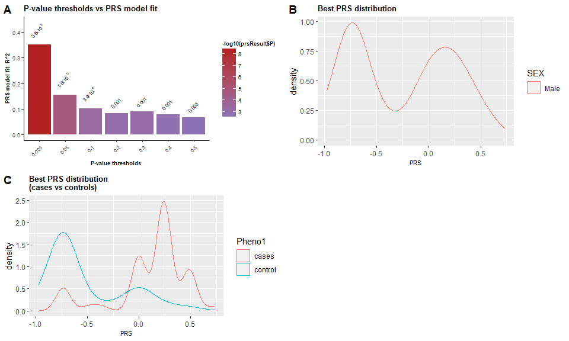

```
## [1] "Plots are printed."
```

```r
## This table shows 10 samples with phenotype, covariates and a PRS column.
PRSmale <- PRSresultmale$PRS
PRSmale[1:10,]
```

| FID | IID | Pheno1 | Sex | AGE | testcovar | PC1 | PC2 | PC3 | PC4 | PC5 | PC6 | SCORE |
| --- | --- | --- | --- | --- | --- | --- | --- | --- | --- | --- | --- | --- |
| EUR_FIN | HG00182 | 1 | 1 | 50 | 1 | 0.1502130 | 0.0166605 | 0.0352041 | -0.0737012 | 0.0481622 | -0.0514214 | -0.7348330 |
| EUR_FIN | HG00183 | 1 | 1 | 58 | 0 | 0.0470950 | -0.0192885 | 0.0462187 | -0.1150680 | 0.1604150 | 0.1977800 | -0.0018333 |
| EUR_FIN | HG00185 | 2 | 1 | 22 | 1 | 0.0855428 | -0.0466448 | -0.0391664 | -0.2283090 | -0.1521040 | -0.0573934 | -0.0018333 |
| EUR_FIN | HG00186 | 2 | 1 | 52 | 0 | 0.0155813 | -0.0178597 | -0.0230120 | -0.1244040 | 0.0063170 | -0.1587840 | 0.0000000 |
| EUR_FIN | HG00187 | 2 | 1 | 49 | 1 | 0.1702040 | 0.0382637 | -0.0553011 | 0.0094718 | -0.0627338 | -0.0664893 | 0.4873330 |
| EUR_FIN | HG00188 | 1 | 1 | 47 | 1 | 0.0753788 | -0.0340385 | 0.1284960 | -0.0137234 | 0.0091291 | -0.0441870 | -0.4883330 |
| EUR_FIN | HG00189 | 1 | 1 | 27 | 1 | 0.1367130 | -0.0930384 | 0.0484504 | 0.1212130 | -0.1974440 | -0.1325780 | -0.7348330 |
| EUR_FIN | HG00190 | 2 | 1 | 42 | 0 | 0.0989251 | 0.1148980 | 0.0278529 | 0.0288093 | -0.0685240 | 0.1815650 | -0.7348330 |
| EUR_FIN | HG00267 | 2 | 1 | 36 | 1 | 0.1039340 | -0.0008894 | -0.1355540 | 0.0746865 | 0.0322867 | 0.0732148 | -0.7348330 |
| EUR_FIN | HG00271 | 2 | 1 | 51 | 1 | 0.1023490 | 0.0131086 | 0.0469537 | 0.1181770 | -0.1008010 | -0.1614050 | 0.2408330 |

```r
## The best threshold
BestPvalue <- PRSresultmale$BestP$Threshold
BestPvalue
```

```
## [1] 0.001
```

**(F) Perform regression to test the association of PRS for a trait in one sex and case status in other sex.**

**PRS ~ trait + PCs + other covariates**

Let’s check the association between PRS and trait in female.

```r
# Running
# First, we need to make fdata object.
famfile <- read.table(paste0(ResultDir,"/femaletarget.fam"))[,c(1,2,6)]
colnames(famfile) <- c("FID","IID","Trait")
prefdata <- merge(famfile, PRS, by = c("IID","FID"))

fdata <- prefdata[,c(13,3:12)]
fdata$Sex <- as.factor(as.character(fdata$Trait))
response_index <- 1
regressor_index <- 2

x <- SexRegress(fdata, regressor_index, response_index)
x
```

```
##     Estimate   Std. Error      t value     Pr(>|t|)
## 1.059080e-02 2.315619e-03 4.573636e+00 1.040039e-05
```

```r
# In this case, there is a significant association between PRS and trait value.
```

## Citation

If you are using GXwasR package and/or following this pipeline in your study, please cite it as:

```r
citation("GXwasR")
```

[output not shown]

## Tutorials Link

**Please follow these tutorials to know more about the functionality of the package GXwasR.**

A list of all the functions in GXwasR:

Tutorial for performing post-imputation QC followed by sex-aware association tests:

Tutorial for performing pre-imputation QC using GXwasR:

Tutorial for performing post-imputation QC using GXwasR:

Tutorial for ancestry estimation:

Tutorial for meta analysis:

Tutorial for heritability estimate and genetic correlation:

Tutorial for gene-based tests:

```
                              ******************* THANK YOU! *************************
```